# Fisseha Berhane, PhD

#### Data Scientist

443-970-2353 fisseha@jhu.edu CV Resume

### Using Amazon Relational Database Service with Python and R

When we analyze data in R or Python, it is a common practice to save data in csv, or other native formats. However, saving our data in a database has many advantages. Using databases has huge advantage when our data is big where loading it is impossible or slows down our analytics. If our data resides in a database, rather than loading the whole data, we can work with subsets or aggregates of the data that we are interested in. This helps to have plenty of memory for our actual analysis. Further, if we have many data files, putting our data in a database, rather than in csv or other format, has better security and is easier to manage. Putting our data in a database is also more convinient for collaboration since we can give access to the tables and operations we want.

In this blog post, we will see how to use R and Python with Amazon Relational Database Service (RDS). Amazon RDS is a distributed relational database service by Amazon Web Services (AWS). It simplifies the setup, operation, and scaling of a relational database for use in applications. Amazon RDS does frequent backups and easy replication across instances and this saves us from losing our data. Amazon RDS cosists of MySQL, MariaDB, PostgreSQL, Oracle, SQL Server and Aurora. In this blog post, we will see how to connect R and Python with MySQL, transfer data to the database, query it and use the queried data for further analysis using Pandas in Python and dplyr in R.

Amazon provides MySQL service for free for one year. You check it [here](https://aws.amazon.com/rds/free/)

#### Launching an AWS Database (DB) instance

1. If you do not have an AWS account, the first step is opening one. You can visit [this](https://aws.amazon.com/rds/free/) to open an account.
2. Once you create an account, click at "Services" at the top left corner and then select "Database RDS"

[figure not shown]

3. Click "Get Started Now" and select "MySQL"

[figure not shown]

4. On the next page, on step 2, select "Dev/Test". Note the production version is not free.

[figure not shown]

5. On the next page, on step 3, specifiy DB details. Make sure to choose free tier by selecting the radio buttion that says "Only show options that are eligible for RDS Free Tier". Provide username and password and make a note of them as we will use them to connect to the database using R and Python.

[figure not shown]

6. On the next page, provide database name and keep a note of the database port (by default it is 3306)

[figure not shown]

7. Once the DB instance is available, you will see the instance Endpoint, which is what we will use to specify the host when we connect R and Python to the database instance.

[figure not shown]

#### Working with AWS RDS MySQL with R

To connect R with the database, we will use the **dplyr** package.

```python
library(dplyr)
```

We use **src_mysql** to connect to MySQL.

```python
host="forrpython.cab6rvva6lca.us-east-1.rds.amazonaws.com"
port=3306
dbname="ForRPython"
user="your_username"
password="your_password"

my_db=src_mysql(dbname=dbname,host=host,port=port,user=user,password=password)
```

To list the tables in the database, we use the **src_tbls** function.

```python
src_tbls(my_db)
```

Since we have not put any tables yet, **src_tbls** dispalys nothing.

##### Put data in the database

###### Data

Now, let's transfer data to the databse. We will transfer flights data from the **nycflights13** package.This dataset contains all 336776 flights that departed from New York City in 2013.

Some information about the data:

```python
library('nycflights13')
paste0("The flights data has ", nrow(flights), " observations and the variables in the dataset are:")
names(flights)
```

'The flights data has 336776 observations and the variables in the dataset are:'

1. 'year'

2. 'month'

3. 'day'

4. 'dep_time'

5. 'sched_dep_time'

6. 'dep_delay'

7. 'arr_time'

8. 'sched_arr_time'

9. 'arr_delay'

10. 'carrier'

11. 'flight'

12. 'tailnum'

13. 'origin'

14. 'dest'

15. 'air_time'

16. 'distance'

17. 'hour'

18. 'minute'

19. 'time_hour'

The following function changes "NA" to "NaN" or empty string. If we have NA in our data frame, our data transfer to a database will fail.

```python
make_mysql_compatible=function(data_frame){
    for(this_col in colnames(data_frame)){
      isna=is.na(data_frame[[this_col]])
      if(any(isna)){
            if(is.numeric(data_frame[[this_col]])){
                data_frame[[this_col]][isna]=NaN
            }
             if(is.character(data_frame[[this_col]])){
                data_frame[[this_col]][isna]=''
            }
          }
        }
    return(data_frame)
    }
```

```python
flights=make_mysql_compatible(flights)
```

###### Transfer data

To upload data to the database, we use the dplyr function **copy_to**. According to the [documentation](https://cran.r-project.org/web/packages/dplyr/vignettes/databases.html), wherever possible, the new object will be temporary, limited to the current connection to the source. So, we have to change temporary to false to make it permament.

```python
copy_to(my_db,flights,temporary = FALSE) # uploading flights data
```

```
Source:   query [?? x 19]
Database: mysql 5.6.27-log [your_username@forrpython.cab6rvva6lca.us-east-1.rds.amazonaws.com:/ForRPython]

    year month   day dep_time sched_dep_time dep_delay arr_time sched_arr_time
   <int> <int> <int>    <dbl>          <int>     <dbl>    <dbl>          <int>
1   2013     1     1      517            515         2      830            819
2   2013     1     1      533            529         4      850            830
3   2013     1     1      542            540         2      923            850
4   2013     1     1      544            545        -1     1004           1022
5   2013     1     1      554            600        -6      812            837
6   2013     1     1      554            558        -4      740            728
7   2013     1     1      555            600        -5      913            854
8   2013     1     1      557            600        -3      709            723
9   2013     1     1      557            600        -3      838            846
10  2013     1     1      558            600        -2      753            745
# ... with more rows, and 11 more variables: arr_delay <dbl>, carrier <chr>,
#   flight <int>, tailnum <chr>, origin <chr>, dest <chr>, air_time <dbl>,
#   distance <dbl>, hour <dbl>, minute <dbl>, time_hour <chr>
```

Now, let's check if the table have been transferred.

```python
src_tbls(my_db)
```

'flights'

We have transfered the data. Now, we can query agaist the database. To connect to a table, we use the **tbl** function. We use the same dplyr verbs that we use in data manipulation to work with databases. dplyr translates the R code we write to SQL code.

```python
flights_DB = tbl(my_db,"flights")
```

```python
class(flights_DB)
```

1. 'tbl_mysql'

2. 'tbl_sql'

3. 'tbl_lazy'

4. 'tbl'

- How many distinct origins are there in the flights table?

```python
cat("Number of Distinct flights:")
flights_DB%>%
      distinct(origin)%>%
      count()
```

```
Number of Distinct flights:
```

```
Source:   query [?? x 1]
Database: mysql 5.6.27-log [your_username@forrpython.cab6rvva6lca.us-east-1.rds.amazonaws.com:/ForRPython]

      n
  <dbl>
1     3
```

- How many flights were made on January first?

```python
filter(flights_DB, month==1, day==1)%>%count()
```

```
Source:   query [?? x 1]
Database: mysql 5.6.27-log [your_username@forrpython.cab6rvva6lca.us-east-1.rds.amazonaws.com:/ForRPython]

      n
  <dbl>
1   842
```

- What is the most common carrier?

```python
flights_DB%>%
      group_by(carrier)%>%
      summarize(Count=n())%>%
      arrange(desc(Count))%>%head(1)
```

```
Source:   query [?? x 2]
Database: mysql 5.6.27-log [your_username@forrpython.cab6rvva6lca.us-east-1.rds.amazonaws.com:/ForRPython]

  carrier Count
    <chr> <dbl>
1      UA 58665
```

- Which months have the highest number of flights?

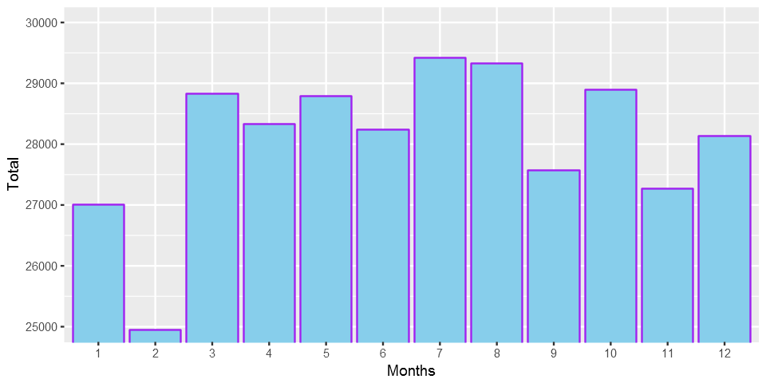

```python
library(ggplot2)

flights_DB%>%
       group_by(month)%>%
       summarize(Total=n())%>%
       collect()%>%
       ggplot(aes(x=as.factor(month),y=Total))+
        geom_bar(stat="identity",color="purple",fill="skyblue")+
        coord_cartesian(ylim = c(25000,30000)) +xlab("Months")
```

- What is the longest distance for each carrier?

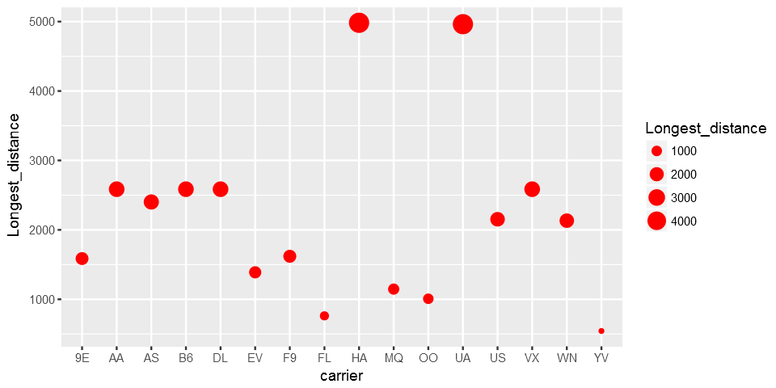

```python
flights_DB%>%
       group_by(carrier)%>%
       summarize(Longest_distance=max(distance))%>%
       collect()%>%
       ggplot(aes(x=carrier,y=Longest_distance))+
       geom_point(color="red",aes(size=Longest_distance))
```

- What are the five most common flight routes?

```python
flights_DB%>%
     group_by(origin,dest)%>%
     summarize(Total_flights=n())%>%
     arrange(desc(Total_flights))%>%
     head(5)
```

```
Source:   query [?? x 3]
Database: mysql 5.6.27-log [your_username@forrpython.cab6rvva6lca.us-east-1.rds.amazonaws.com:/ForRPython]
Groups: origin

  origin  dest Total_flights
   <chr> <chr>         <dbl>
1    JFK   LAX         11262
2    LGA   ATL         10263
3    LGA   ORD          8857
4    JFK   SFO          8204
5    LGA   CLT          6168
```

- Is the carrier with the highest departure delay also with the highest arrival delay?

```python
cat("The Carrier with the highest departure delay is ")
flights_DB%>%
     group_by(carrier)%>%
     summarize(Highest_departure_delay=max(dep_delay))%>%
     arrange(desc(Highest_departure_delay))%>%
     head(1)
```

```
The Carrier with the highest departure delay is
```

```
Source:   query [?? x 2]
Database: mysql 5.6.27-log [your_username@forrpython.cab6rvva6lca.us-east-1.rds.amazonaws.com:/ForRPython]

  carrier Highest_departure_delay
    <chr>                   <dbl>
1      HA                    1301
```

```python
cat("The Carrier with the highest arrival delay is ")
flights_DB%>%
     group_by(carrier)%>%
     summarize(Highest_arrival_delay=max(arr_delay))%>%
     arrange(desc(Highest_arrival_delay))%>%
     head(1)
```

```
The Carrier with the highest arrival delay is
```

```
Source:   query [?? x 2]
Database: mysql 5.6.27-log [your_username@forrpython.cab6rvva6lca.us-east-1.rds.amazonaws.com:/ForRPython]

  carrier Highest_arrival_delay
    <chr>                 <dbl>
1      HA                  1272
```

- Are the unique destinations the same in all months?

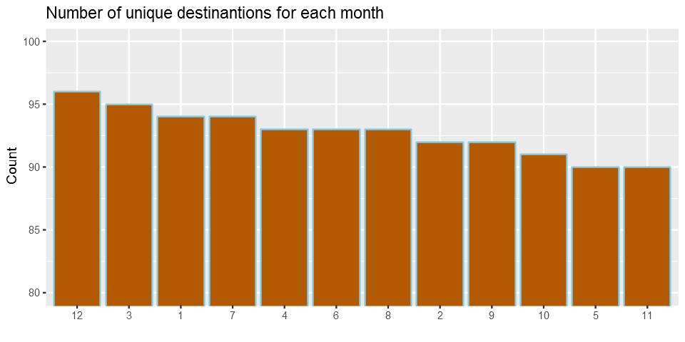

```python
flights_DB%>%
      distinct(dest, month)%>%
      group_by(month)%>%
      summarize(distinct_destinations=n())%>%
      collect()%>%
      mutate(month = factor(month,levels = month[order(distinct_destinations,decreasing =T)]))%>%
      ggplot(aes(x=month,y=distinct_destinations))+
          geom_bar(stat='identity',color='skyblue',fill='#b35900')+
          xlab("")+ggtitle('Number of unique destinantions for each month')+
          ylab('Count')+coord_cartesian(ylim = c(80,100))
```

#### Working with AWS RDS MySQL with Python

We will use the **pymysql** package to connect to the database. After that, we will use Pandas for data analysis.

```python
import pandas as pd
import pymysql
```

##### Connect to database

To connect to the database, we use the **connect** function from **pymysql**. The connect function returns a Connection object.

```python
host="forrpython.cab6rvva6lca.us-east-1.rds.amazonaws.com"
port=3306
dbname="ForRPython"
user="your_username"
password="your_password"

conn = pymysql.connect(host, user=user,port=port,
                           passwd=password, db=dbname)
```

- How many distinct origins are there in the flights table?

```python
pd.read_sql('select count(distinct origin) AS "Distinct Origins" from flights;', con=conn)
```

|  | Distinct Origins |
| --- | --- |
| 0 | 3 |

- How many flights were made on January first?

```python
pd.read_sql('select count(year)  from flights where month=1 AND day=1;', con=conn)
```

|  | count(year) |
| --- | --- |
| 0 | 842 |

- What is the most common carrier?

```python
pd.read_sql('select carrier, count(*) AS Total from flights group by carrier order by Total desc  limit 1;', con=conn)
```

|  | carrier | Total |
| --- | --- | --- |
| 0 | UA | 58665 |

- Which months have the highest number of flights?

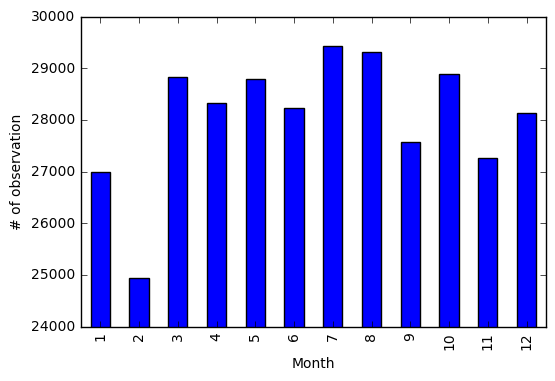

```python
%matplotlib inline
import matplotlib.pyplot as plt
pandas_df=pd.read_sql('select month from flights;', con=conn)
pandas_df.groupby(pandas_df.month).size().plot(kind='bar',ylim =[24000,30000])
plt.xlabel('Month')
plt.ylabel('# of observation')
plt.show()
```

- What is the longest distance for each carrier?

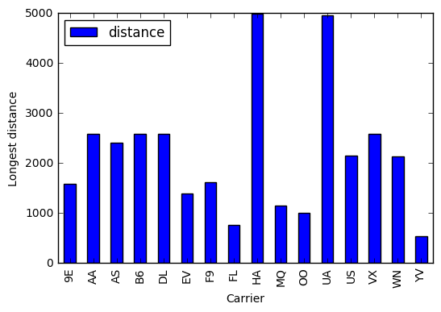

```python
pandas_df=pd.read_sql('select carrier, distance  from flights ;', con=conn)
pandas_df.groupby(pandas_df.carrier).max().plot(kind='bar')
plt.xlabel('Carrier')
plt.ylabel('Longest distance')
plt.show()
```

- What are the five most common flight routes?

```python
pandas_df=pd.read_sql('select origin, dest, count(*) as Total  from flights group by origin, dest order by Total desc limit 5 ;', con=conn)
pandas_df
```

|  | origin | dest | Total |
| --- | --- | --- | --- |
| 0 | JFK | LAX | 11262 |
| 1 | LGA | ATL | 10263 |
| 2 | LGA | ORD | 8857 |
| 3 | JFK | SFO | 8204 |
| 4 | LGA | CLT | 6168 |

- Is the carrier with the highest departure delay also with the highest arrival delay?

```python
highest_departure_delay=pd.read_sql('select carrier, max(dep_delay) as Highest_departure_delay  from flights group by carrier order by Highest_departure_delay desc limit 1 ;', con=conn)
highest_arrival_delay=pd.read_sql('select carrier, max(arr_delay) as Highest_arrival_delay  from flights group by carrier order by Highest_arrival_delay desc limit 1 ;', con=conn)
```

```python
print(highest_departure_delay)
```

```
  carrier  Highest_departure_delay
0      HA                   1301.0
```

```python
print(highest_arrival_delay)
```

```
  carrier  Highest_arrival_delay
0      HA                 1272.0
```

- Are the unique destinations the same in all months?

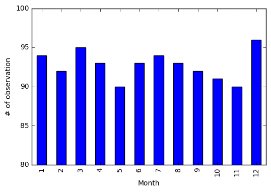

```python
pandas_df=pd.read_sql('select distinct month,dest from flights ;', con=conn)
pandas_df.groupby(pandas_df.month).size().plot(kind='bar',ylim =[80,100])
plt.xlabel('Month')
plt.ylabel('# of observation')
plt.show()
```

[comments powered by Disqus](http://disqus.com)